# Practical Machine Learning Project

Antonio González Huete

26/07/2014

The first thing that we need to do in a machine learning approach, it is to analize the accesible data. This way we can select the relevant features that will allow us to inference the desired output. For that, we first will load the data from the file:

```r
  pmlTraining <- read.csv(file="/home/antonio/Descargas/Johns Hopkins - Practical Machine Learning/Assigments/pml-training.csv", head=TRUE, sep=",", na.strings=c("#DIV/0!",NA))
  pmlTesting  <- read.csv(file="/home/antonio/Descargas/Johns Hopkins - Practical Machine Learning/Assigments/pml-testing.csv" , head=TRUE, sep=",", na.strings=c("#DIV/0!",NA) )
```

In the actual case, we can see that the number of invalid data (or not available data) is much bigger than the relevant data:

```r
sum( colSums( is.na(pmlTraining)) ) / sum( colSums( !is.na(pmlTraining)) )
```

```
## [1] 1.585
```

For that reason, one logical step is to eliminate the irrelevant data to facilitate the inference process:

- Removing the columns with a determined porcentage of NA (in this case superior to the 0.0%):

```r
    pmlTrainingSet <- pmlTraining[ , colSums( is.na(pmlTraining)) <= nrow(pmlTraining)*0.0]
    pmlTestingSet  <- pmlTesting [ , colSums( is.na(pmlTraining)) <= nrow(pmlTraining)*0.0]
```

- Removing the first column for being the index:

```r
    pmlTrainingSet <- pmlTrainingSet[, -1]
    pmlTestingSet  <- pmlTestingSet [, -1]
```

- And in this particular case removing non numeric features (names, etc), but previously we will store the output fields for later:

```r
    pmlTrainingClass <- factor(pmlTrainingSet$classe)
    pmlTestingId     <- pmlTestingSet$problem_id
    pmlTrainingSet   <- pmlTrainingSet[ , sapply(pmlTrainingSet, is.numeric)==TRUE]
    pmlTestingSet    <- pmlTestingSet [ , sapply(pmlTrainingSet, is.numeric)==TRUE]
```

With respect to the final validation set, we will select only the features selected for the training:

```r
    pmlTestingSet  <- pmlTestingSet [ , which(names(pmlTestingSet) %in% names(pmlTrainingSet))]
```

At this point we have already reduced the number of fields to the most relevant ones. And at this point, one could train the system directly, but in my case and due to the configuration of my system, a directly training over the remaining fields did give to me an “out of memory”. Due by that, I decided to perform a dimensional reduction using PCA (in this case not for increment the accuracy, it was for computational efficency):

```r
  library(caret)
  pre <- preProcess(pmlTrainingSet, method="pca", thres=0.95)
  pmlTrainingSet <- predict(pre, pmlTrainingSet)
  pmlTestingSet  <- predict(pre, pmlTestingSet )
```

Finally, we end with a very reduced training set, having a final dimension of:

```
## [1] 19622    26
```

from the original dimension:

```
## [1] 19622   160
```

Now we are in a position of train the system, so we add the output fields to the data sets, and we perform a partition over the training set to avoid overfiting, and to get an unbiased evaluation of our predictor:

```r
  pmlTrainingSet$classe    <- pmlTrainingClass
  pmlTestingSet$problem_id <- pmlTestingId
  inTrain  <- createDataPartition(y=pmlTrainingSet$classe, p=0.75, list=FALSE)
  trainSet <- pmlTrainingSet[ inTrain, ]
  testSet  <- pmlTrainingSet[-inTrain, ]
```

Now, before we select a method for train the system, we give a look over the data and visualize it with respect the first two principal components (the two components that gives the most amount of information):

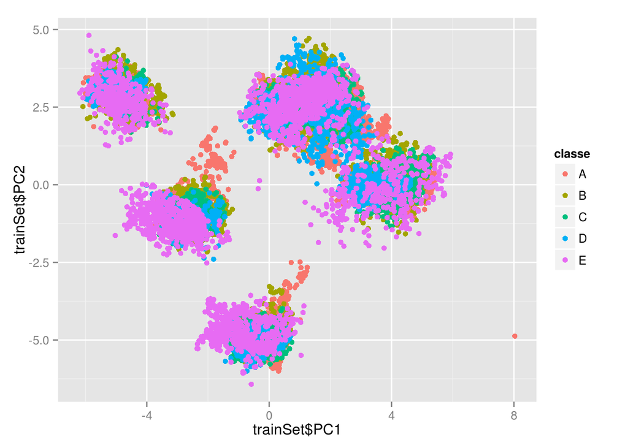

It clearly shows a high non-lineality nature for this problem, which means that we will need a non-linear method to reach good results. With that, we select to use a random forest method for various reasons:

- First and most important, by be a non-linear method.
- Second, because it have implicit a bootstrap method.
- And third, because it have demostrated to be one of the most powerfull classifiers seen in the course.

Then, finally we train the system with a random forest:

```r
    set.seed(123456)
    m <- train(classe ~ ., data=trainSet, method="rf")
```

Once the system have been trained, we need to evaluate it with an unknown data (the test cases):

```r
  predictions <- predict(m, newdata=testSet)
```

As we can see in the following results, we have an accuracy over the 97% in the test set, which it is a very good one:

```
## Confusion Matrix and Statistics
##
##           Reference
## Prediction    A    B    C    D    E
##          A 1390    8    3    3    0
##          B    2  932   13    2    2
##          C    2    9  829   35    4
##          D    0    0    9  762    2
##          E    1    0    1    2  893
##
## Overall Statistics
##
##                Accuracy : 0.98
##                  95% CI : (0.976, 0.984)
##     No Information Rate : 0.284
##     P-Value [Acc > NIR] : < 2e-16
##
##                   Kappa : 0.975
##  Mcnemar's Test P-Value : 0.000962
##
## Statistics by Class:
##
##                      Class: A Class: B Class: C Class: D Class: E
## Sensitivity             0.996    0.982    0.970    0.948    0.991
## Specificity             0.996    0.995    0.988    0.997    0.999
## Pos Pred Value          0.990    0.980    0.943    0.986    0.996
## Neg Pred Value          0.999    0.996    0.994    0.990    0.998
## Prevalence              0.284    0.194    0.174    0.164    0.184
## Detection Rate          0.283    0.190    0.169    0.155    0.182
## Detection Prevalence    0.286    0.194    0.179    0.158    0.183
## Balanced Accuracy       0.996    0.989    0.979    0.973    0.995
```

For a last validation of that we have done all right, we plot the missed cases:

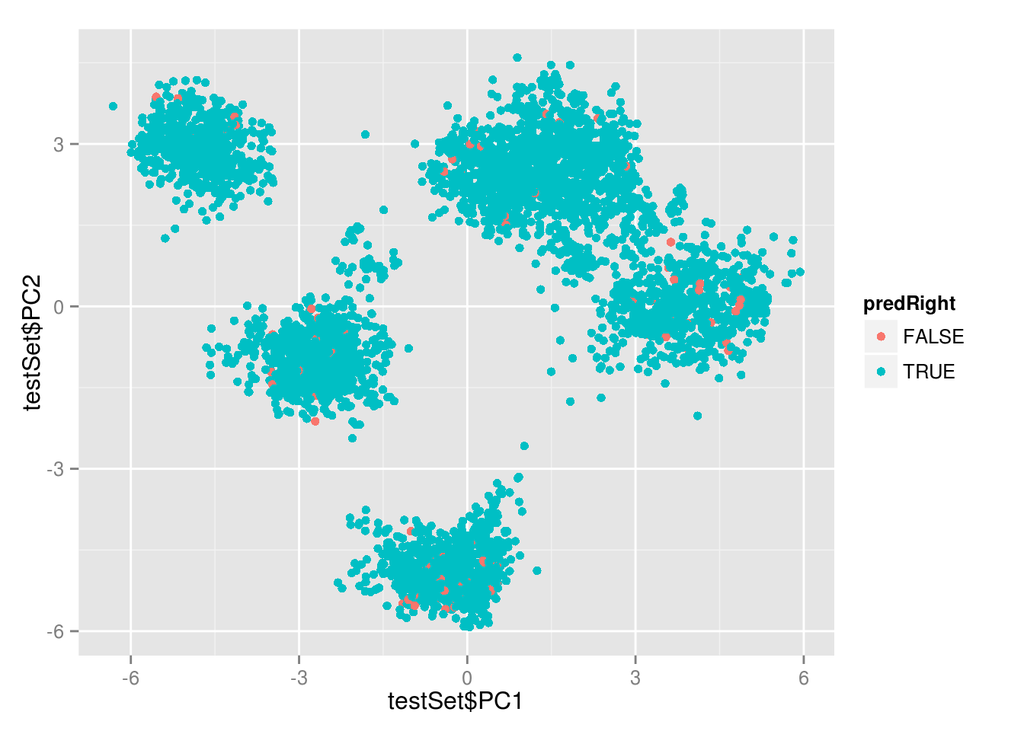

Which shows that clearly we really have inferred the results in a good way, we have only a very few missed values that are not concentrated in the same area, and which with much probability it will be produced by an lack or excess of learning (it is probable that refining a little more the selected features, this missed cases could be avoid).

With all of that, we could evaluate the provided final validation test set, where we obtaining only one error from the total 20 cases:

```r
  answers  <- predict(m, newdata=pmlTestingSet)
```

```
##  [1] B A A A A E D B A A B C B A E E A B B B
## Levels: A B C D E
```